# 35. 最小二乗法と最尤法

Masahiko Asano

2022-09-10

- このセクションで使う `R パッケージ`一覧

```r
library(tidyverse)
library(stargazer)
library(patchwork)
```

- `Plobit Model` や `Logit Model` のような非線形モデルでは、`OLS` 推定は使えない  
  → 最尤法 (`MLE: maximum likelihood esitmation`) を使って推定する

# 1. 最小二乗法と最尤法の違い

- 最尤法は「さいゆうほう」と読む
- 最も尤（もっと）もらしい方法という意味

| 最小二乗法 (OLS) | 不偏性・効率的 (BLUE) |
| --- | --- |
| 最尤法(MLE) | 一致性・効率的・サンプル数が十分に大きければ正規分布 |

- 次のような事例を考える
- 試験の答案を返された
- 10点満点中、自分の試験点数は「4 点」
- これは良い点なのか、悪い点なのか？
- **調べる方法**：回りの友人達の点数を聞いてみる
- 友人 4 人の点数を確かめた (6, 7, 3, 5点)
- 自分の点数を含めて 5 つのサンプル**（サンプルの平均値は 5）**  
  ← 3 + 4 + 5 + 6 + 7 = 25 ÷ 5 = 5
- 5 人分サンプルから母平均（試験全体の平均値）を推定する

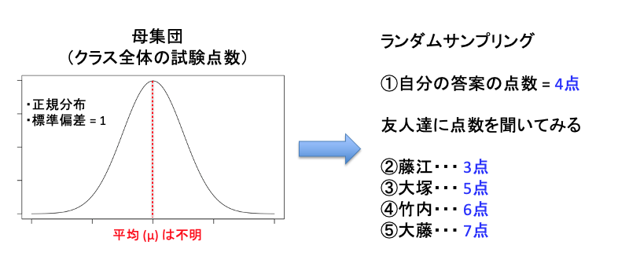

- この母集団の特徴
1. 正規分布
2. 標準偏差 = 1
3. 母平均 ($μ$) は不明
- **OLS とMLE の基本的な考え方：**

| 最小二乗法 (OLS) | 得られた**サンプルの外れ度合いを最小にする母平均**は？ |
| --- | --- |
| 最尤法 (MLE) | 得れた**サンプルを生み出す蓋然性 (likelihood) を最大にする母平均**は？ |

**クラス全体の試験の平均値($μ$) がもし 5 点なら**

- 平均 5、標準偏差 1 の正規分布の確率密度関数を使えば、母集団からサンプルを取った時に、それが「3 点である蓋然性」「4 点である蓋然性」「5 点である蓋然性」「6 点である蓋然性」「7 点である蓋然性」を計算できる

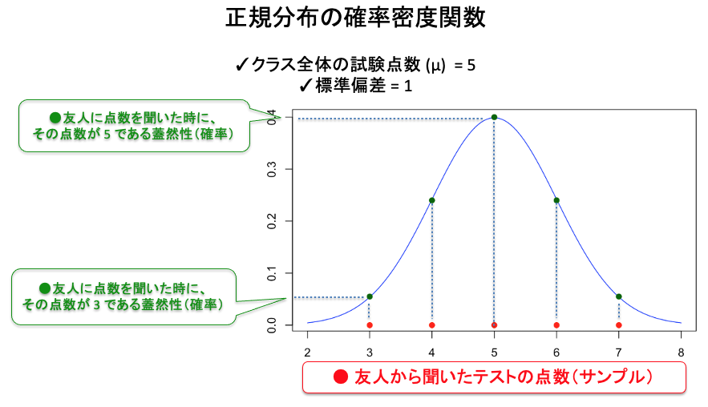

**5 個のサンプルを同時に取得する蓋然性（`μ = 5` の場合）**

- この 5 個のサンプルが無為作為に取られたのであれば、この 5 個のサンプルを同時に取得する蓋然性は次の式で求められる

(3である蓋然性) x (4である蓋然性) x (5である蓋然性) x (6である蓋然性) x (7である蓋然性)

**クラス全体の試験の平均値($μ$) がもし 6 点なら**  
- 平均 6、標準偏差 1 の正規分布の確率密度関数を使えば、母集団からサンプルを取った時に、それが「3 点である蓋然性」「4 点である蓋然性」「5 点である蓋然性」「6 点である蓋然性」「7 点である蓋然性」を計算できる

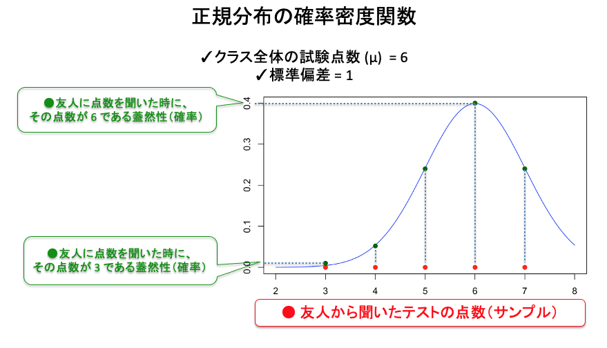

**5 個のサンプルを同時に取得する蓋然性（`μ = 6` の場合）**

- この 5 個のサンプルが無為作為に取られたのであれば、この 5 個のサンプルを同時に取得する蓋然性は次の式で求められる

(3である蓋然性)x (4である蓋然性) x (5である蓋然性) x (6である蓋然性) x (7である蓋然性)

**クラス全体の試験の平均値($μ$) が 4, 5, 6 点の場合の比較**

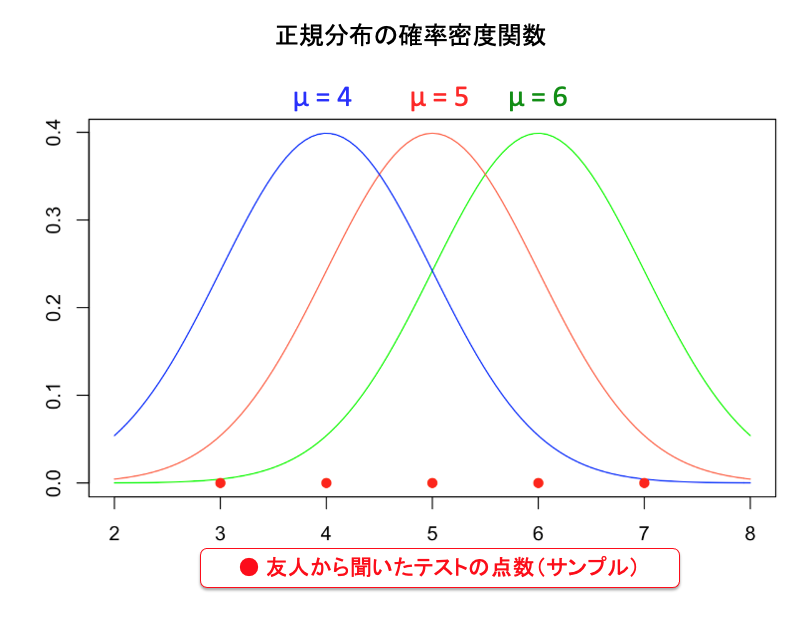

- これらの平均値（$μ$）の値の中で、どれが尤（もっと）もありえそう (`likely`) な値か?  
  **→ 蓋然性がもっとも大きくなる $μ$**
- ここでは「サンプルデータを生み出す蓋然性を最大化するような平均値（$μ$）の値」は**「5 個のサンプルの平均値」**
- これを「母集団の μ の推定値」として使う・・・最尤法 (`MLE`) の考え方

**尤度（ゆうど）**

- 母集団からランダムに採取したサンプルが得られる蓋然性のこと
- 尤度は私たちが推定したい母集団のパラメータ（例えば母平均 $μ$ など）によって決まる
- 最尤法 (`MLE`) は、尤度を最大化するような値をパラメータの推定値として使う

**尤度関数 (`likelihood function`)**

- 尤度をパラメータを用いた式で表したもの
- 実際には、計算のしやすくするため、尤度関数の対数をとって**対数尤度関数**を使う

最尤法 (MLE) による推定方法 ・尤度関数を求める  
・尤度関数を最大化するようなパラメータの値を解く

# 2. 最尤法による具体的な計算方法

| パラメータの計算方法 | 詳細 |
| --- | --- |
| 解析的 (analytical) 方法 | この方法で最尤法はなかなか解けない |
| 数値的 (numerical)方法 | Newton-Raphson法、BHHH法、DFP法、BFGS法などを使って**数値的 (numerical) に解く** |

## 2.1 数値演算的方法によるパラメータの計算方法

- 最尤法による推定は、解析的 (`analytical`) な推定は困難  
  → 数値的 (`numerical`) に解く  
  → 単純計算が特異なコンピュータに解いてもらう

## 2.2 当てはまりの良さの指標

- `MLE` における推定値 = サンプルデータを生成する蓋然性 (= 尤度)
- 尤度を使って、モデルの善し悪しを評価する

| **最尤推定法 (MLE)** | **最小二乗法 (OLS)** |
| --- | --- |
| 尤度比検定 (`likelihood ratio test: LR test`)・・・問題あり | F 検定 |
| 疑似決定係数 (pseudo $R^2$)・・・問題あり |  |

OLS における F 検定の解説 - F 検定では複数の帰無仮説を同時に検定する  
- 複数の帰無仮説を**同時に**検定する理由:  
→ 1 つずつ検定すると有意でないが、全体で検定する有意なことがありうるから

**検定の方法:**

→ 2 つのモデルを作る  
(1) 無制限モデル (`unrestricted model`) — `β1` と `β2` を含むモデル  
(2) 制限モデル (`restricted model`) — `β1` と `β2` を含まないモデル  
→ それぞれの $R^2$ を計算  
→ 「`β1` と `β2` を含むことによって、 $R^2$ が十分に増えたか？」を検定

`MLE` における尤度比検定 `(LR test`) の解説と問題点

**検定の方法:**

→ 2 つのモデルを作る  
(1) 無制限モデル (`unrestricted model`) — `β1` と `β2` を含むモデル  
(2) 制限モデル (`restricted model`) — `β1` と `β2` を含まないモデル  
→ それぞれの $R^2$ を計算

→ 「`β1` と `β2` を含むことによって、 尤度が十分に増えたか？」を検定

**尤度比検定の問題点**

「モデル全体（説明変数の組み合わせが）無意味かどうか」というおおざっぱな評価しかできない

`MLE` における疑似決定係数 (pseudo $R^2$)の解説と問題点  
- `OLS` における決定係数 ($R^2$) に類似した概念として考案

$$pseudoR^2 =1 -
\frac{無制約モデルの対数尤度}{ 制約モデルの対数尤度}$$

- 無制約モデルが尤度を改善しない → 擬似決定係数は 0 に近づく
- 無制約モデルが尤度を改善した → 擬似決定係数は 1 に近づく

**疑似決定係数 (pseudo $R^2$) の限界**

- 決定係数 ($R^2$) と違って、疑似決定係数 (pseudo $R^2$) は「目的変数の変化のうちのどれほどを当該モデルが説明しているか」という指標として解釈できない
- 複数の擬似決定係数 (pseudo $R^2$) を比較して「こちらの方がいいモデル」とはいえない
- 調整済み決定係数 (Adjusted $R^2$) と違って、擬似決定係数 (pseudo $R^2$) は説明変数を増やしたことによる調整もされない  
  **→ 擬似決定係数は、ほとんど無意味な数値**

**解決策**

- 赤池情報量基準 (`AID: Akaike information criterion`) を使う

$$AIC =
-2×対数尤度+2×パラメータ数$$

- `AIC` が最小のモデルが「最も良いモデル」とされる
- 多くの説明変数を使っても(= パラメータ数が増えても)、それに応じた分だけ尤度が増加しなければ、そのモデルは「良いモデル」とは言えない

| **最尤推定法 (MLE)** | **最小二乗法 (OLS)** |
| --- | --- |
| 尤度 | 決定係数 ($R^2$) |
| AIC | 調整済み決定係数 (Adjusted $R^2$) |

**まとめ**

- `MLE` における尤度は、`OLS` における決定係数 ($R^2$) に相当
- `MLE` における `AIC` は、`OLS` における調整済み決定係数 (Adjusted $R^2$)に相当
- `AIC` は `MLE` におけるモデルの評価基準として最も広く使われている

# 3. 総選挙データを使った比較

## 3.1 `OLS` と `MLE` の前提条件

- **量的な応答変数**の場合・・・**線形回帰 (`OLS`)** を用いる
- **質的な応答変数**の場合・・・**非線形回帰 (`MLE`)** を用いる
- `OLS` では推定できない非線形モデルでも `MLE` は推定できる
- `OLS` で前提としている仮定を `MLE` では明示的にモデル中に取り込める
- ここでは本来 `MLE` で分析すべきモデルを `OLS` で分析するとどうなるかを示す

## 3.2 データの準備 (`hr96-17.csv`)

- 衆議院議員総選挙の得票データ hr96-17.csv をダウンロード  
  → `RProject folder`内の `data` フォルダに入れる
- `data`フォルダ内から `read_csv` で読み取り `df` というデータフレーム名をつける

```r
df <- read_csv("data/hr96-17.csv", na = ".")
```

```r
names(df)
```

```
 [1] "year"          "pref"          "ku"            "kun"
 [5] "wl"            "rank"          "nocand"        "seito"
 [9] "j_name"        "gender"        "seshu_dummy"   "jiban_seshu"
[13] "name"          "previous"      "...15"         "age"
[17] "exp"           "status"        "vote"          "voteshare"
[21] "eligible"      "turnout"       "castvotes"     "...24"
[25] "...25"         "nojiban_seshu" "mag"
```

- 2012年の総選挙と必要な 5 つの変数を抜き出し `df1` と名前を付ける

```r
df1 <- df %>%
  filter(year == 2012) %>%
  select(wl, seshu_dummy, exp, eligible, status)
```

- `wl = 1` は小選挙区当選者、`wl = 2` は復活当選者、`wl = 0` は落選者
- これを次のように変更：
- `wl = 1` が当選者（小選挙区と比例復活）, `wl = 0` が落選者

```r
df1 <- mutate(df1, wl = as.numeric(wl == 1 | wl == 2))
```

- `exp` と `eligible` を使って、有権者一人あたりに使う選挙費用 (`exppv`) を作る

```r
df1 <- mutate(df1, exppv = exp / eligible) # eligible は小選挙区ごとの有権者数
```

```r
summary(df1$exppv)
```

```
    Min.  1st Qu.   Median     Mean  3rd Qu.     Max.     NA's
 0.00126  6.10793 14.86928 17.18456 23.65808 94.59168       14
```

- `status = 0` は新人、`status = 1` は現職、 `status = 2` は元職
- これを次のように変更：
- `status = 0` がその他、`status = 1` が現職

```r
df1 <- mutate(df1, inc = as.numeric(status == 1 ))
```

```r
df1 <- df1 %>%
  select(wl, seshu_dummy, inc, exppv)
```

- これら変数の記述統計は次のとおり
- `R-Markdown` で `html` 表示する際にはチャンクオプションで `{r, results = “asis”}` と指定する。

```r
stargazer(as.data.frame(df1),
          type ="html",
          digits = 2)
```

| Statistic | N | Mean | St. Dev. | Min | Max |
| --- | --- | --- | --- | --- | --- |
| wl | 1,294 | 0.33 | 0.47 | 0 | 1 |
| seshu_dummy | 1,294 | 0.10 | 0.30 | 0 | 1 |
| inc | 1,294 | 0.31 | 0.46 | 0 | 1 |
| exppv | 1,280 | 17.18 | 13.50 | 0.001 | 94.59 |

| 変数名 | 詳細 |
| --- | --- |
| wl | 選挙の当落: 1 = 当選（小選挙区＋復活当選）、0 = 落選 |
| seshu_dummy | 世襲候補者ダミー: 1 = 世襲、0 = 非世襲（地盤世襲 or 非世襲） |
| inc | 現職ステータス: 1 現職、0 = 非現職 |
| exppv | 有権者一人あたりに費やす選挙費用（円） |

## 3.3 `OLS モデル`と `MLE モデル`の比較

- ここでは2012年の総選挙における候補者の「選挙での当落 (`wl`)」が応答変数
- wl は 0 が落選、1 が当選の 2 値変数（ダミー変数）

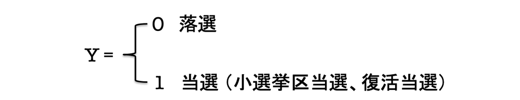

**$\mathrm{選挙の当落 = β_0 + β_1世襲+ β_2現職 + β_3選挙費用 +ε }$**

- 線形回帰で得られる $\mathrm{β_1,β_2, β_3}$ が $\mathrm{Pr(当落|X)}$ の推定値
- 線形回帰 (`OLS`) を行うと、推定値が区間`[0, 1]`から外れてしまうことがある  
  → これでは「確率」とは言えない
- それでも、この予測値は順序付けのために使うことができる
- 「確率」の大雑把な大雑把な推定値として使うことが可能
- `OLS` では誤差項 (`ε`) が正規分布しているという仮定がある  
  →`OLS` では次の仮定を置いていることになる

$$「選挙の当落」は 「β_0 + β_1世襲+
β_2現職 + β_3選挙費用」を平均に正規分布している$$

- ここで使う応答変数 (`wl`) の分布は次のとおり

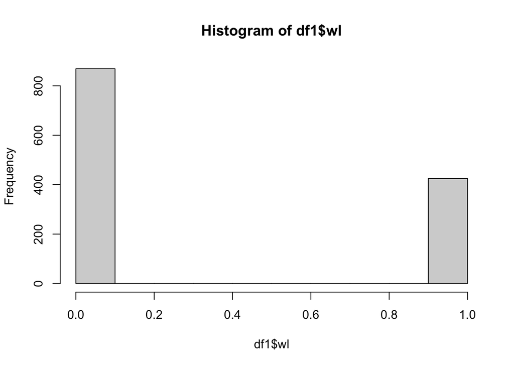

```r
hist(df1$wl)
```

- 応答変数 (`wl`) は 0, 1 の値をとる「二値変数」
- この応答変数 (`wl`) は上記の `OLS` の仮定を満たさない  
  → これは`OLS` ではなく `MLE` で分析すべき
- 「良いモデル」という観点から、`MLE` で分析すべきモデルを `OLS` で分析してみる
- `MLE` 推定では「一般化線形モデル」(`GLM: generalized linear model`) の一つ である Logit モデル（ロジスティック回帰）を使う

| モデル名 | 応答変数 | 説明変数 |
| --- | --- | --- |
| OLS | 選挙の当落 (wl) | 世襲 (seshu_dummy), 現職 (inc), 選挙費 (exppv) |
| MLE (Logit) | 選挙の当落 (wl) | 世襲 (seshu_dummy), 現職 (inc), 選挙費 (exppv) |

**OLS モデル（重回帰）: (`lm 関数`)**

```r
ols <- lm(wl ~ seshu_dummy + inc + exppv,
          data = df1)
```

**Logit モデル（ロジスティック回帰） (`glm 関数`)**

```r
logit <- glm(wl ~ seshu_dummy + inc + exppv, data = df1,
               family = binomial(link = "logit"))　# 誤差を二項分布に指定
```

## 3.4 分析結果の表示

```r
stargazer(ols, logit,
          type = "html",
          digits = 2)
```

|  | *Dependent variable:* |  |
| --- | --- | --- |
|  | wl |  |
|  | *OLS* | *logistic* |
|  | (1) | (2) |
| seshu_dummy | 0.35*** | 1.94*** |
|  | (0.04) | (0.28) |
| inc | -0.01 | -0.12 |
|  | (0.03) | (0.16) |
| exppv | 0.02*** | 0.09*** |
|  | (0.001) | (0.01) |
| Constant | 0.04** | -2.53*** |
|  | (0.02) | (0.14) |
| Observations | 1,280 | 1,280 |
| R<sup>2</sup> | 0.29 |  |
| Adjusted R<sup>2</sup> | 0.29 |  |
| Log Likelihood |  | -607.20 |
| Akaike Inf. Crit. |  | 1,222.40 |
| Residual Std. Error | 0.40 (df = 1276) |  |
| F Statistic | 176.75*** (df = 3; 1276) |  |
| *Note:* | p<0.1; p<0.05; p<0.01 |  |

推定値の比較

**OLS モデルの推定結果**

- 回帰式の `Intercept` の係数: `0.04` が意味すること `seshu_dummy = 0, inc = 0, exppv = 0` の候補者が当選する値は **0.04**  
  → これは「確率」とは言えない  
  それでも、この予測値は順序付けのために使うことができる  
  「確率」の大雑把な大雑把な推定値として使うことが可能  
  → `seshu_dummy = 0, inc = 0, exppv = 0` の候補者が当選する値は **4%**

**Logit モデルの推定結果**

```r
exp(-2.51)
```

```
[1] 0.08126824
```

- もし `Odds` の値が 1 であれば、当選する確率は 50 %  
  → ここでは `Odds` の値が 0.08 なので当選確率は 50% より遙かに小さいとわかる
- その当選確率を計算してみる

```r
predict(logit, type = "response",
        newdata = data_frame(seshu_dummy = 0, inc = 0, exppv = 0))
```

```
         1
0.07404419
```

- `logit` における`seshu_dummy = 0, inc = 0, exppv = 0` の候補者の当選確率は `0.075 (= 7.5%)`
- 参考：`OLS` における `seshu_dummy = 0, inc = 0, exppv = 0` の時の切片は `0.04 (= 4%)`

## 3.5 グラフによる比較

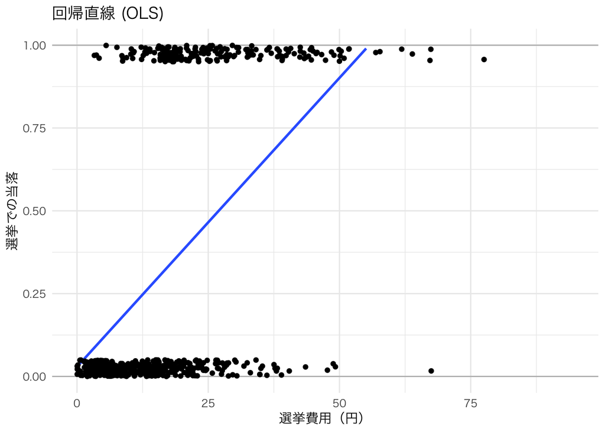

```r
OLS <- ggplot(df1, aes(x = exppv, y = wl)) +
  geom_smooth(method = "lm", se = FALSE) +
  labs(x = "選挙費用（円）", y = "選挙での当落", title = "回帰直線 (OLS)") +
  geom_hline(yintercept = c(0, 1), color = "gray") +
  geom_jitter(width = 0.05, height = 0.05) +
  ylim(0,1) +
  theme_minimal(base_family = "HiraKakuProN-W3")
print(OLS)
```

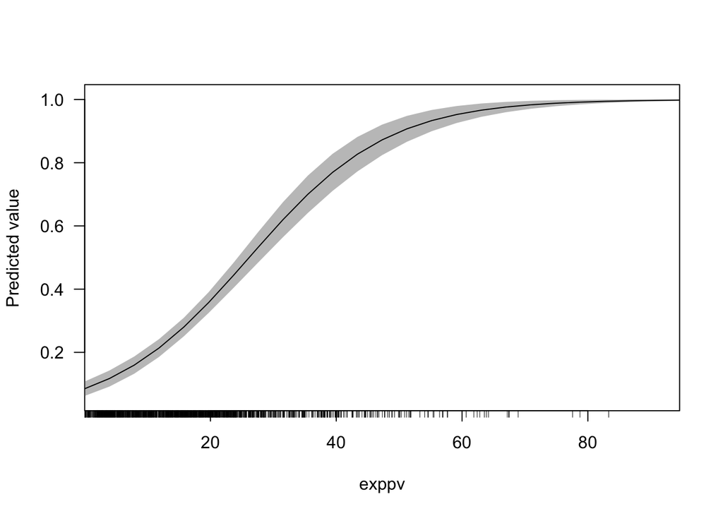

```r
LOGIT <- margins::cplot(logit,
                  x = "exppv",
                  what = "prediction") %>%
  as_data_frame() %>%
  ggplot(aes(x = xvals, y = yvals, ymin = lower, ymax = upper)) +
  geom_ribbon(fill = "gray") +
  geom_line() +
labs(x = "選挙費用（円）",
     y = "予測当選確率の予測値",
     title = "選挙費用と予測当選確率 (logit)") +
  theme_minimal(base_family = "HiraKakuProN-W3")
```

- 二つのグラフを並べて表示させる

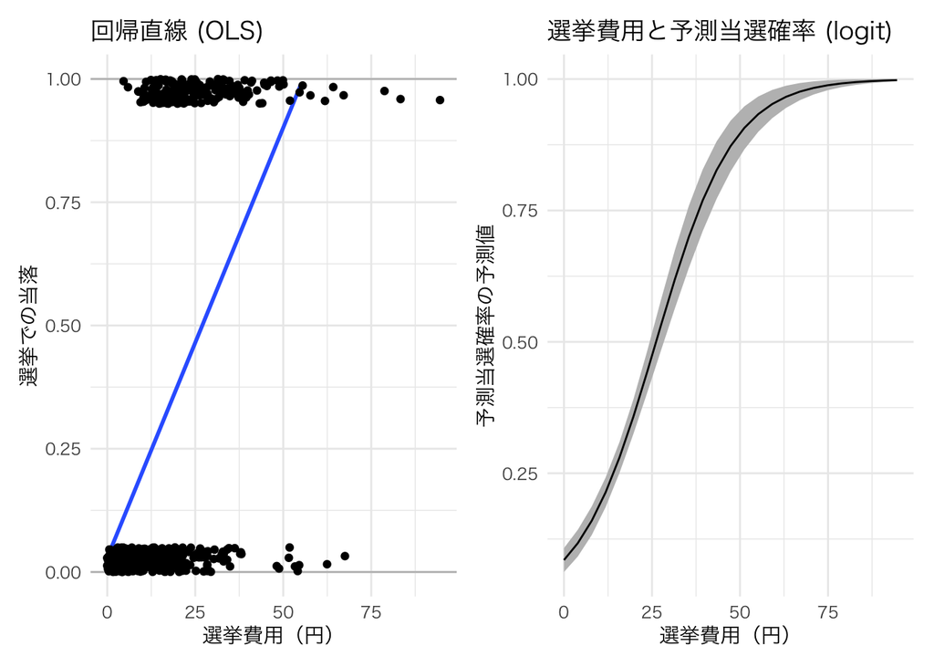

```r
OLS + LOGIT
```

## 3.6 分析結果の解釈

- 上の右側のグラフは、世襲 (`seshu_dummy`) と現職 (`inc`) の値を平均値に固定した時に「有権者一人あたりに費やした選挙費用」とその「候補者の当選確率」の関係を示している
- 例えば、この平均的な候補者が有権者一人あたりに選挙費用として 25円使うと、その候補者の当選確率は約 47% だと予想できる
- R を使うと、次のように計算できる

```r
predict(logit, type = "response",
        newdata = data_frame(seshu_dummy = 0.09, inc = 0.31, exppv = 25))
```

```
       1
0.470656
```

- 候補者一人あたりの選挙資金を50円使うと、その候補者の当選確率は約 90% まで上がる

```r
predict(logit, type = "response",
        newdata = data_frame(seshu_dummy = 0.09, inc = 0.31, exppv = 50))
```

```
        1
0.8961336
```

```r
predict(logit, type = "response",
        newdata = data_frame(seshu_dummy = 1, inc = 1, exppv = 25))
```

```
        1
0.8269272
```

- **モデルのあてはまり (`fit`) 比較**  
  `OLS` モデル と `Logit` モデルの `AIC` を比較

```r
AIC(ols)
```

```
[1] 1263.786
```

```r
AIC(logit)
```

```
[1] 1222.399
```

まとめ - 応答変数が 0, 1 の二値変数を `OLS` モデルと `Logit` モデルで分析  
→ ほぼ同様の結果  
- この分析では `AIC` が小さい **`Logit` モデルの方がより良いモデル**といえる  
→ **質的な応答変数**の場合には**非線形回帰 (`MLE`)** を用いた方がより良い

**参考文献**

- [宋財泫 (Jaehyun Song)・矢内勇生 (Yuki Yanai)「私たちのR: ベストプラクティスの探究」](https://www.jaysong.net/RBook/)
- [土井翔平（北海道大学公共政策大学院）「Rで計量政治学入門」](https://shohei-doi.github.io/quant_polisci/data-import.html)
- [矢内勇生（高知工科大学）授業一覧](http://yukiyanai.github.io/teaching/)
- 浅野正彦, 矢内勇生.『Rによる計量政治学』オーム社、2018年
- 浅野正彦, 中村公亮.『初めてのRStudio』オーム社、2018年
- Winston Chang, R Graphics Cookbook, O’Reilly Media, 2012.
- Kieran Healy, DATA VISUALIZATION, Princeton, 2019
- Kosuke Imai, Quantitative Social Science: An Introduction, Princeton University Press, 2017